# Transformations

# Normality inducing transformations

## Adding missing feature as a normality inducing transformation

The Linear Regression model is $$ \y = \Theta^T \x + \epsilon $$

As explained before, Regression produces a conditional probability $$ \pr{\hat{\y} | \x} $$

where $\hat{\y}$ and $\epsilon$ are *Normally distributed variables*.

Assumptions of the Linear Regression model are violated if

- $\epsilon$ is not Normal
- the individual $\epsilon^\ip$ display a pattern
- the individual $\epsilon^\ip$ have different variances (hetero skedatic)

One reason for failure of these assumptions is a missing feature

- "curvy" data set and Linear model
  - we saw pattern of errors: larger in tails
  - variances increased in tail

Adding a feature (e.g.,second order polynomial term for the curvy data set) can be seen as a normality inducing transformation.

## Log transformation

We've seen this in our lecture on Logistic Regression

- the probabilites are *not* normally distributed
- the odds are *not* normally distributed
- the *log odds* **is** normally distributed

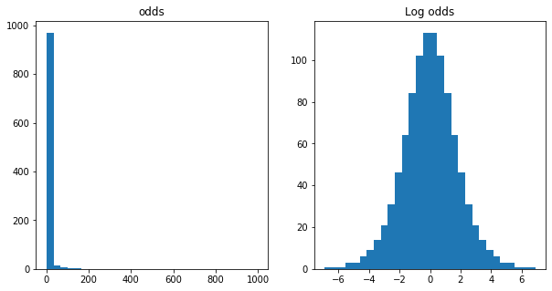

```python
tf = tmh.TransformHelper()
tf.plot_odds()
```

$$ \begin{array}{llll} \hat{p} \over {1- \hat{p}} & = & { 1 \over { 1 + e^{-s} } } \over { 1 - {1 \over { 1 + e^{-s} } } } \\ & = & { 1 \over { 1 + e^{-s} } } \over { {1 + e^{-s} -1} \over {1 + e^{-s}} } \\ & = & 1 \over {e^{-s}} \\ & = & e^{s} \end{array} $$

So `LogisticRegression` is really just a `LinearRegression` with a transformed target

$$ \textrm{log}( {\hat{p} \over {1- \hat{p}}}) = \Theta^T \cdot x $$

# Other transformations

## Centering

Transforming a feature to have mean $0$.

$$ \x^\ip_j = \x^\ip_j - \bar{\x}_j $$

- low values now become negative
  - more clearly indicates deletrious effect than a low, positive number
  - example: Star Ratings for movies
- some algos (PCA) need centered data

## Bucketing/Binning

- Target may be linear in a feature only in broad ranges of the feature
  - income vs age
    - very young (below working age) all income is identical (0)
    - very old (above retirement) - no job related income
  - Latitude/Longitude
    - small changes matter MUCH less than big changes
- Converts numerical feature
  - into categorical $\mathbf{Is \; bucket \; 1}, \mathbf{Is \; bucket \; 2}, \ldots$
  - ordinal: replace value with center value of bin

Bucket size choices:

- Equal spaced buckets
- Equal quantile buckets

**Lesson** Don't fit a square peg (non-linear response) into a round hole (linear model)

## Outliers

Pull in extreme values to reduce their influence on the fit.

- Clipping, Winsorization

# Feature engineering example: Geron Housing Data

Geron housing data

## Data: California Housing Prices Data (AG Chapt 2)

```python
housing = tm.load_housing_data()
housing.head()
```

|  | longitude | latitude | housing_median_age | total_rooms | total_bedrooms | population | households | median_income | median_house_value | ocean_proximity |
| --- | --- | --- | --- | --- | --- | --- | --- | --- | --- | --- |
| 0 | -122.23 | 37.88 | 41.0 | 880.0 | 129.0 | 322.0 | 126.0 | 8.3252 | 452600.0 | NEAR BAY |
| 1 | -122.22 | 37.86 | 21.0 | 7099.0 | 1106.0 | 2401.0 | 1138.0 | 8.3014 | 358500.0 | NEAR BAY |
| 2 | -122.24 | 37.85 | 52.0 | 1467.0 | 190.0 | 496.0 | 177.0 | 7.2574 | 352100.0 | NEAR BAY |
| 3 | -122.25 | 37.85 | 52.0 | 1274.0 | 235.0 | 558.0 | 219.0 | 5.6431 | 341300.0 | NEAR BAY |
| 4 | -122.25 | 37.85 | 52.0 | 1627.0 | 280.0 | 565.0 | 259.0 | 3.8462 | 342200.0 | NEAR BAY |

Each row represents a district

Goal is to predict Median House Value in the district.

- Features
  - total_rooms: number of rooms in the district
  - total_bedrooms: number of bedrooms in the district
  - households; number of households in the district
  - population: number of people in the district
  - median_income: median income of people in the district
- Target
  - median_house_value: median value of a house in the district

What potential issues pop out ?

Some *raw* features depend on the *size* of the district, so can't compare the same feature across districts.

- total_rooms, total_bedrooms, households, population

### Feature engineering: Normalization

The first transformation is a kind of normalization

- adjusting a feature for the size of the district
  - divide district aggregate by number of items in the district
- makes the feature comparable across districts of different sizes

```python
housing["rooms_per_household"] = housing["total_rooms"]/housing["households"]
housing["bedrooms_per_room"] = housing["total_bedrooms"]/housing["total_rooms"]
housing["population_per_household"]=housing["population"]/housing["households"]
```

By synthesizing ratios:

- rooms/household
- population/household
- bedrooms/room

we have transformed the raw features into processed features that will probably be better predictors

### Feature engineering: Bucketing and Clipping

- Will $1 more of income *really* predict higher housing prices in the district ?
  - create income buckets
    - Disclaimer
      - In the book this is **not** a feature but something used to "stratify" the sample
      - We are taking a bit of artistic license to make a point

```python
print("Median income ranges from {min:.1f} to {max:.1f}".format(min=housing["median_income"].min(),
                                                                max=housing["median_income"].max()
                                                               ))
# Divide by 1.5 to limit the number of income categories
housing["income_cat"] = np.ceil(housing["median_income"] / 1.5)

print("Income buckets")
housing["income_cat"].value_counts()
```

```
Median income ranges from 0.5 to 15.0
Income buckets
```

```
3.0     7236
2.0     6581
4.0     3639
5.0     1423
1.0      822
6.0      532
7.0      189
8.0      105
9.0       50
11.0      49
10.0      14
Name: income_cat, dtype: int64
```

Still a lot of buckets. One theory is that incomes above bucket 5 don't predict housing prices, so clip.

```python
# Label those above 5 as 5
housing["income_cat_clipped"] = housing["income_cat"].where(housing["income_cat"] < 5, 5.0)
print("Income buckets")
housing["income_cat_clipped"].value_counts()
```

```
Income buckets
```

```
3.0    7236
2.0    6581
4.0    3639
5.0    2362
1.0     822
Name: income_cat_clipped, dtype: int64
```

```python
print("Done")
```

```
Done
```